# Hijacking DLLs in Windows

Wietze Beukema

October 2020

[figure not shown]

# Hello, who dis?

### Wietze Beukema

- Threat Hunting
- Detection Engineering & Research
- PwC UK, London

Keep in touch!

[figure not shown]

[@Wietze](https://www.twitter.com/wietze)

[figure not shown]

github.com/wietze

[figure not shown]

wietze.beukema@pwc.com

# 👾 DLL Hijacking

# What’s in a name?

[figure not shown]

_

# DLL Hijacking

“Tricking a legitimate/trusted application into loading an arbitrary DLL”

# DLL Hijacking (2)

- **T1574** : Hijack Execution Flow
  - **T1574.001**: DLL Search Order Hijacking
  - **T1574.002**: DLL Side-Loading

But why?

- Your evil code, executed by a trusted executable
- Great for Execution, Persistence, Privilege Escalation
- The threat is real

# Types

## A few common ones

[output not shown]

# Types

## 1: DLL replacement

> “Replace a legitimate DLL with the evil DLL.”
- Most basic type
- Could run DLL with high integrity (although replacement usually requires this too)

### Example

Copy `evil.dll` to `c:\windows\system32\propsys.dll`, replacing the existing DLL. Now run `c:\windows\system32\netplwiz.exe`. *Execution*!

[figure not shown]

# Types

## 2: DLL search order hijacking

> “Place the evil DLL in a location that is searched for before the legitimate DLL.”
- Look at the *DLL search order*: (1) Directory of application → (2) System32 directory → (3) System directory → (4) Windows directory → (5) Current directory → (6) `%PATH%`
- CVE potential: especially executables running with high integrity
- Good way to find these: look for `FILE NOT FOUND` in Procmon

### Example

Vault7 Leaks: portable Chrome tries to load `DWrite.dll`, located in `System32\`. Because no absolute path is specified, the directory of the application is tried first [[1](https://wikileaks.org/ciav7p1/cms/page_27492385.html)]. *Execution* + *Persistence*!

# Types

## 3: Phantom DLL Hijacking

> “Drop the evil DLL in place of a missing/non-existing DLL that a legitimate application tries to load.”
- More rare, yet not uncommon
- Less likely your DLL will break the running application
- CVE potential

### Example

Vault7 leaks: Kaspersky process `avp.exe` intended to load `WHEAPGRD.DLL`. Due to a bug, it would prepend the drive letter, meaning it would try to load non-existing file `CWHEAPGRD.DLL` [[2](https://wikileaks.org/ciav7p1/cms/page_3375327.html)]. *Execution* + *Persistence*!

# Types

## 4: DLL redirection

> “Change the location in which the DLL is searched for, by editing %PATH% or .exe.manifest / .exe.local.”

# Types

## 5: WinSxS DLL replacement

> “Replace the legitimate with the evil DLL in the relevant WinSxS folder of the targeted DLL.”
- Sometimes referred to as ‘DLL Side-Loading’

# Types

## 6: Relative path DLL Hijacking

> “Copy (and optionally rename) the legitimate application to a user-writeable folder, alongside the evil DLL.”
- Simple: DLL Hijacking with least preconditions
- No CVE/LOLbin potential, yet very powerful
- Combine with other techniques for more impact, e.g. UAC bypass

### Example

Ocean Lotus/APT32 embedded the legitimate `system32\` executable `rekeywiz.exe` alongside an evil `duser.dll` in one of their phishing documents. After unpacking, the trusted `rekeywiz.exe` would load the malicious `duser.dll` which would start phase 2 of the attack [3, [4](https://any.run/report/f08ccc040c8d8db60f30a6d1026aa6523e97c6cf52b1b30f083a830a0a65a3a9/3abfc241-3ab0-4016-acbb-040b44199d52)]. *Execution*!

[figure not shown]

# Types

## 6: Relative path DLL Hijacking (2)

> “Copy (and optionally rename) the legitimate application to a user-writeable folder, alongside the evil DLL.”
- Nearly 300 (!) `system32\` executables are vulnerable to this [[5](https://wietze.github.io/blog/hijacking-dlls-in-windows)]
- Can be combined with UAC bypass techniques

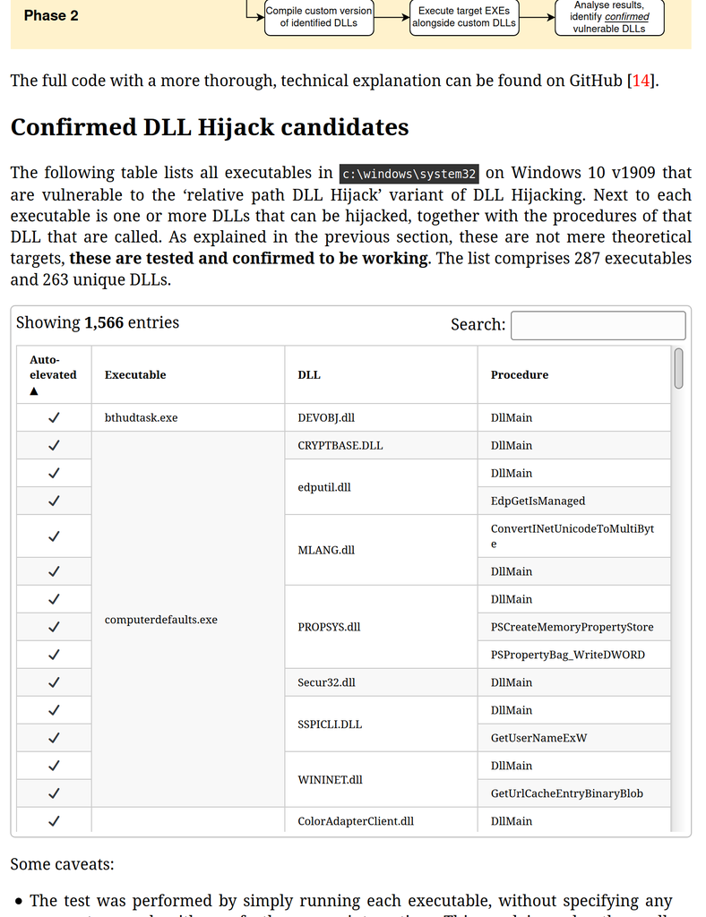

# 🧭 Prevention & Detection

# Preventing DLL Hijacking

[output not shown]

### Nevertheless: the problem remains!

# Detecting DLL Hijacking

## It’s not straightforward…

A few (flawed) ideas:

- Look for known DLL hijack targets (DLL names, executables) [[7](https://github.com/wietze/windows-dll-hijacking/blob/master/possible_windows_dll_hijacking.yml)]
- Look for creation of DLLs by unexpected processes
- Look for common targets (e.g. Microsoft-signed executables) in unexpected locations
- Look for common targets loading DLLs not on VT
- …

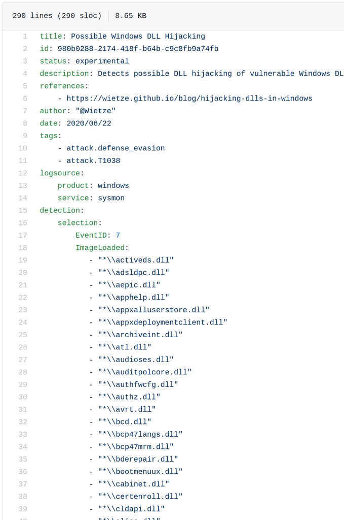

# Detecting DLL Hijacking (2)

- 🔎 Instead of just looking for the DLL Injection, look for the **behaviour that follows**
- 📚 **Layer your defences**!
- 🛡️ Ensure a **broad base** of behavioural rules, hunting techniques, anomaly detection

# Thank you

This content is for general information purposes only, and should not be used as a substitute for consultation with professional advisors.  
© 2020 PricewaterhouseCoopers LLP. All rights reserved. PwC refers to the UK member firm, and may sometimes refer to the PwC network. Each member firm is a separate legal entity. Please see www.pwc.com/structure for further details.